# Analysis of Hate Speech Tweets from HASOC conference

Andrea Grillandi

6/6/2020

**Importing libraries**

```r
library("tidyverse")
library("readr")
library("party")
library("stats")
library("caret")
library("pROC")
library("lme4")
library("lmerTest")
library(gridExtra)
library(dplyr)
library(arm)
library(languageR)
library(influence.ME)
library(boot)
```

*Function for accuracy testing*

```r
lrAcc <- function(lrMod, responseVar){
  ## convert response variable into a factor if it's not one
  if(!is.factor(model.frame(lrMod)[,responseVar])){
    model.frame(lrMod)[,responseVar] <- as.factor(model.frame(lrMod)[,responseVar])
  }
    ## model predictions in log-odds
    preds = predict(lrMod, newdata=model.frame(lrMod))
    ## transform to 0/1 prediction
    preds <- ((sign(preds)/2)+0.5)

    ## response variable values, transformed to 0/1
    y <- (as.numeric(model.frame(lrMod)[,responseVar])-1)

    ## how often is prediction the same as the actual response
    acc <- sum(preds==y)/length(preds)

    return(acc)
}
```

This function was taken from http://people.linguistics.mcgill.ca/~morgan/book/mixed-effects-logistic-regression.html#evaluation-measures

## 1. Introduction - Research objectives and hypothesis

Hate speech is a phenomenon strongly associated to the Internet and, more specifically, to social networks. Hate Speech can be defined as any sort of expression intended to cause offense or harm, basing on ethnicity, sexual orientation, political affiliation, religious beliefs or any other kind of social identifier. This is just a partial definition of the phenomenon, a more detailed explanation can be found on Rahman (2020).  
### HASOC HASOC is a Shared Task on Hate Speech and Offensive Content Identification in Indo-European Languages, which was launched in 2019 (hasocfire). The task is intended to stimulate research in Hate Speech automatic detection. It is based on 3 annotated datasets for English, German and Hindi languages. The texts were manually annotated by two groups of human supervisors, according to the official paper of the shared task conference (Thomas Mandl et al., 2019). The idea for this reasearch stems from a personal interest for automatic analysis of written text extracted from social media and, in general, from a fascination for the idea of social networks as a mirror of people’s sentiments that can be more or less automatically analysed.

### Hypothesis

In this paper, I am going to test whether a text that was identified as containing Hate Speech presents different linguistic parameters, such as noun frequency, than a text which does not contain Hate Speech. In a similar fashion, I am going to test the hypothesis that hateful texts contain more misspells than non-hateful texts. Two-sample unpaired t-test will be run on the parameters of the dataset to compare Hate Speech and non-Hate-Speech texts. Moreover, I will construct some Logistic Regression models using the dataset features. Further on, the parameters will be passed to a Decision Tree and a Random Forest classifier and their *feature importance* will be measured. In this research, only English and German datasets were considered, so to simplify the preprocessing part.

## 2. Research Design

Data from HASOC consists of posts that were extracted from Twitter and Facebook for all the three languages, according to keywords and hashtags with offensive content (hasocfire). Texts from the English and German datasets were preprocessed to extract parameters that were then used for statistical testing and for the classification models.

### Formal hypotheses

First of all I am going to test whether hateful posts contain more misspells than non-hateful ones. I will test this hypothesis using a two-sample unpaired and one-tailed t-test, as the sample sizes are unequal (a more detailed description will follow). The hypothesis is based on the fact that the user writing such hateful posts might be in an emotional state that could make him or her mistype some words.
H0:
$$misspell\_count_{NOT} \lt misspell\_count_{HOF}$$
,
H1:
$$misspell\_count_{NOT} \gt misspell\_count_{HOF}$$
,
where NOT stands for non-hateful content and HOF for hateful content.

Further, I will run an unpaired two-tailed t-test for every linguistical parameter that was extracted during the preprocessing: punctuation, noun, proper noun, adjective and verb frequencies in the texts, and eventually absolute text length.
H0:
$$param\_frequency_{NOT} \lt param\_frequency_{HOF}$$
,
H1:
$$param\_frequency_{NOT} \gt param\_frequency_{HOF}$$
.

Moreover I will construct four Logistic Regression models for each dataset, in order to predict whether the text is HOF or NOT. The first two models are multiple logistic regression models, one with features misspell_count and text_length, while the second with features misspell_count, text_length and noun_freq. I will also train two mixed-effect logistic regression models (the distribution of features is the same as in the normal models), with the assumption that text_length, misspell_count and noun_freq have both a random (varying across text samples) and a fixed effect (always constant). I will use the functions *glm* and *glmer*.

Eventually, I will train a decision tree and a random forest classifier using the functions *ctree* and *cforest* from *party* R library. The parameters passed to the classifier will be the ones which were already presented above in the text (misspells frequency, linguistic param frequencies). After that, I will run the *varimp* function on the Random Forest model to get an overview of the interaction of the parameters.

## 3. Data collection method

Datasets and Python code used for the preprocessing are accesible through github (link in Bibliography). Datasets for English and German language in tsv format were downloaded directly from the HASOC Shared Task website (link in Bibliography). The posts in the two datasets were further processed using Python.

### Preprocessing

Posts from the datasets were cleaned from urls, and usernames beginning with an address sign (@). Subsequently, punctuation frequency, which is punctuation count over text length, was calculated. A column with text length for each post was also added to both datasets.  
Later on, I ran a spellchecker on each text using Python library pyspellchecker, which is language independent. The function from this library is based on Peter Norvig’s spellchecking algorithm (link to library in Bibligraphy). Misspells were counted and then frequency related to text length was calculated.  
The last step was running a POS tagger on the posts. For English I used nltk *pos_tag* function. In the table below, an overview of the tags that were included in the groups of nouns, proper nouns, adjectives, and verbs, respectively. Again, the count of each of the 4 group was then divided by the text length.

| POS tags | description |
| --- | --- |
| NN | singular noun |
| NNS | plural noun |
| ———————————- |  |
| NNP | singular proper noun |
| NNPS | plural proper noun |
| ———————————– |  |
| JJ | adjective |
| JJR | comparative adjective |
| JJS | superlative adjective |
| ———————————– |  |
| VB | verb, base form |
| VBD | verb, past tense |
| VBG | verb, gerund |
| VBN | verb, past participle |
| VBP | verb, present |
| VBZ | verb, present 3rd pers |
| ———————————– |  |

The same was done for German posts. In this case, however, I used Python library HanTa, which contains a function for POS-tagging for German language (link in Bibliography). In the table below an overview of the tags that were considered as nouns, proper nouns, adjectives, or verbs.

| POS tags | description |
| --- | --- |
| NA | adjective used as noun |
| NN | noun |
| ———————————- |  |
| NE | proper noun |
| ———————————– |  |
| ADJA | attributive adjective |
| ADJD | predicative adjective |
| ———————————– |  |
| VVFIN | finite |
| VVIMP | imperative |
| VVINF | infinitive |
| VVPP | past participle |
| ———————————– |  |

All the parameters were organized in two new tsv tables (one for each language) and further used for statistical analysis.

## 4. Data description

HASOC datasets were annotated for three different tasks. However, this research is based on the annotation that was produced only for the first of this tasks. Task 1 was offered for all the three languages. According to Mandl T. et al., it is a coarse-grained binary classification in which participants are required to classify posts into two classes, namely: Hate and Offensive (HOF) and Non-Hate and offensive (NOT). During the annotation, posts were labeled as HOF if they contained Hate Speech, aggression or profanity, otherwise they were labeled as NOT. In R, I also added a column called **binary_classification**, were 1 == HOF and 0 == NOT.

A frequency higher than 1 in punct_freq means that in the post there were more punctuation signs than words the tokenizer could catch.

Below the summaries of the datasets follow.

*English dataset*

```r
df_eng <- read.csv("https://raw.githubusercontent.com/lauberto/uni_mydirectory/master/data_analysis/preprocessed_datasets/english_dataset_project.tsv", sep="\t")
df_eng <- df_eng[df_eng$task_1 != "task_1",]
df_eng <- droplevels(df_eng)
df_eng <- subset(df_eng, select = -c(text_id, text, task_2, task_3))
df_eng["language"] = "eng"
df_eng$language <- as.factor(df_eng$language)
df_eng$binary_classification <- ifelse(df_eng$task_1 == "HOF", 1, 0)
df_eng$binary_classification <- as.factor(df_eng$binary_classification)
summary(df_eng)
```

```
##        X        task_1       punct_freq     misspell_count     text_length
##  Min.   :   1   HOF:2261   Min.   :0.0000   Min.   :0.00000   Min.   : 3.00
##  1st Qu.:1464   NOT:3591   1st Qu.:0.1698   1st Qu.:0.09524   1st Qu.:17.00
##  Median :2926              Median :0.2353   Median :0.15385   Median :27.00
##  Mean   :2926              Mean   :0.2542   Mean   :0.17456   Mean   :29.09
##  3rd Qu.:4389              3rd Qu.:0.3182   3rd Qu.:0.23529   3rd Qu.:40.00
##  Max.   :5852              Max.   :1.5714   Max.   :0.75000   Max.   :79.00
##    noun_freq      propnoun_freq         adj_freq         verb_freq
##  Min.   :0.0000   Min.   :0.000000   Min.   :0.00000   Min.   :0.00000
##  1st Qu.:0.2093   1st Qu.:0.000000   1st Qu.:0.05882   1st Qu.:0.08333
##  Median :0.2609   Median :0.000000   Median :0.10000   Median :0.13333
##  Mean   :0.2716   Mean   :0.005577   Mean   :0.11066   Mean   :0.13171
##  3rd Qu.:0.3214   3rd Qu.:0.000000   3rd Qu.:0.15385   3rd Qu.:0.17857
##  Max.   :0.8333   Max.   :0.625000   Max.   :0.52381   Max.   :0.66667
##  language   binary_classification
##  eng:5852   0:3591
##             1:2261
##
##
##
##
```

*German dataset*

```r
df_de <- read.csv("https://raw.githubusercontent.com/lauberto/uni_mydirectory/master/data_analysis/preprocessed_datasets/german_dataset_project.tsv", sep="\t")
df_de <- df_de[df_de$task_1 != "task_1",]
df_de <- droplevels(df_de)
df_de <- subset(df_de, select = -c(text_id, text, task_2, task_3))
df_de["language"] = "de"
df_de$language <- as.factor(df_de$language)
df_de$binary_classification <- ifelse(df_de$task_1 == "HOF", 1, 0)
df_de$binary_classification <- as.factor(df_de$binary_classification)
summary(df_de)
```

```
##        X          task_1       punct_freq     misspell_count    text_length
##  Min.   :   1.0   HOF: 407   Min.   :0.0000   Min.   :0.0000   Min.   : 1.00
##  1st Qu.: 955.2   NOT:3411   1st Qu.:0.1471   1st Qu.:0.4074   1st Qu.:14.00
##  Median :1910.5              Median :0.2143   Median :0.4737   Median :26.00
##  Mean   :1910.2              Mean   :0.2320   Mean   :0.4876   Mean   :26.75
##  3rd Qu.:2864.8              3rd Qu.:0.2927   3rd Qu.:0.5455   3rd Qu.:39.00
##  Max.   :3819.0              Max.   :2.0000   Max.   :1.0000   Max.   :72.00
##    noun_freq       propnoun_freq        adj_freq         verb_freq
##  Min.   :0.00000   Min.   :0.00000   Min.   :0.00000   Min.   :0.00000
##  1st Qu.:0.07407   1st Qu.:0.03571   1st Qu.:0.04348   1st Qu.:0.03922
##  Median :0.11765   Median :0.07843   Median :0.08333   Median :0.07454
##  Mean   :0.12039   Mean   :0.11738   Mean   :0.09410   Mean   :0.07379
##  3rd Qu.:0.16667   3rd Qu.:0.14286   3rd Qu.:0.12821   3rd Qu.:0.10638
##  Max.   :1.00000   Max.   :1.00000   Max.   :0.66667   Max.   :0.50000
##  language  binary_classification
##  de:3818   0:3411
##            1: 407
##
##
##
##
```

*Full dataset*

```r
full_df <- rbind(df_eng, df_de)
summary(full_df)
```

```
##        X        task_1       punct_freq     misspell_count    text_length
##  Min.   :   1   HOF:2668   Min.   :0.0000   Min.   :0.0000   Min.   : 1.00
##  1st Qu.:1210   NOT:7002   1st Qu.:0.1615   1st Qu.:0.1333   1st Qu.:16.00
##  Median :2418              Median :0.2258   Median :0.2632   Median :27.00
##  Mean   :2525              Mean   :0.2454   Mean   :0.2982   Mean   :28.17
##  3rd Qu.:3627              3rd Qu.:0.3077   3rd Qu.:0.4444   3rd Qu.:40.00
##  Max.   :5852              Max.   :2.0000   Max.   :1.0000   Max.   :79.00
##    noun_freq      propnoun_freq        adj_freq         verb_freq
##  Min.   :0.0000   Min.   :0.00000   Min.   :0.00000   Min.   :0.00000
##  1st Qu.:0.1290   1st Qu.:0.00000   1st Qu.:0.05263   1st Qu.:0.06061
##  Median :0.2083   Median :0.00000   Median :0.09302   Median :0.10526
##  Mean   :0.2119   Mean   :0.04972   Mean   :0.10412   Mean   :0.10884
##  3rd Qu.:0.2857   3rd Qu.:0.06250   3rd Qu.:0.14286   3rd Qu.:0.15385
##  Max.   :1.0000   Max.   :1.00000   Max.   :0.66667   Max.   :0.66667
##  language   binary_classification
##  eng:5852   0:7002
##  de :3818   1:2668
##
##
##
##
```

## 5. Exploratory data analysis, descriptive statistics and visualization.

### Parameters correlation visualization

In order to have a general idea of the distribution of data, boxplots of the distribution of different parameters in German and English will be shown.

*Frequency of misspells*

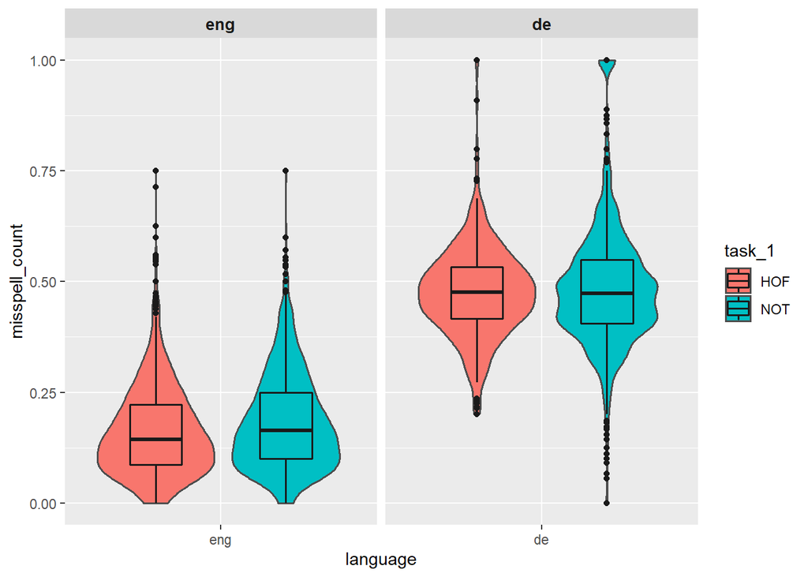

```r
p_punct <- ggplot(full_df, aes(x=language, y=misspell_count, fill=task_1))
dodge <- position_dodge(width=1)
p_punct + geom_violin(size=0.6, color="grey30", position=dodge) +
geom_boxplot(width=0.4, size=0.6, color="grey10", position=dodge, color="grey") +
facet_grid(cols = vars(language), scales="free", space="free") +
theme(
    strip.text.x = element_text(
      size = 10, face = "bold"
      ),
    strip.text.y = element_text(
      size = 10, face = "bold"
      )
)
```

*Frequency of punctuation*

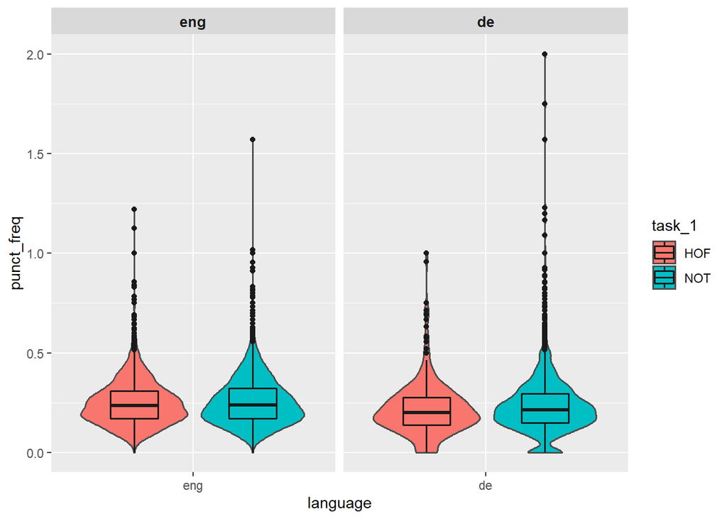

```r
p_punct <- ggplot(full_df, aes(x=language, y=punct_freq, fill=task_1))
dodge <- position_dodge(width=1)
p_punct + geom_violin(size=0.6, color="grey30", position=dodge) +
geom_boxplot(width=0.4, size=0.6, color="grey10", position=dodge, color="grey") +
facet_grid(cols = vars(language), scales="free", space="free") +
theme(
    strip.text.x = element_text(
      size = 10, face = "bold"
      ),
    strip.text.y = element_text(
      size = 10, face = "bold"
      )
    )
```

*Frequency of nouns*

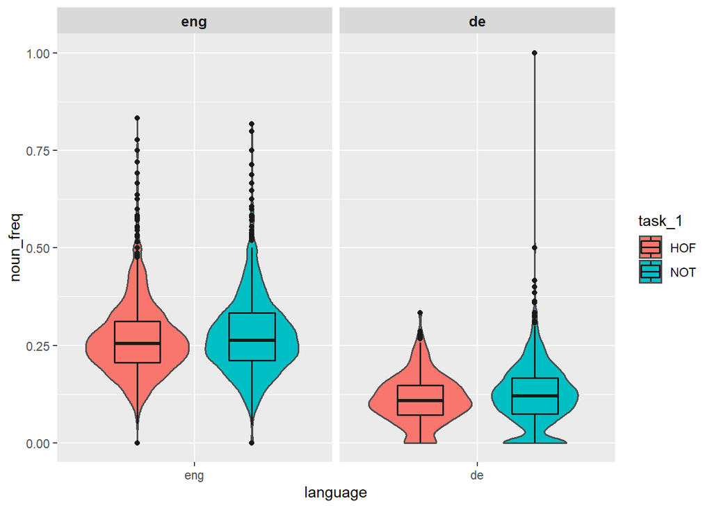

```r
p_punct <- ggplot(full_df, aes(x=language, y=noun_freq, fill=task_1))
dodge <- position_dodge(width=1)
p_punct + geom_violin(size=0.6, color="grey30", position=dodge) +
geom_boxplot(width=0.4, size=0.6, color="grey10", position=dodge, color="grey") +
facet_grid(cols = vars(language), scales="free", space="free") +
theme(
    strip.text.x = element_text(
      size = 10, face = "bold"
      ),
    strip.text.y = element_text(
      size = 10, face = "bold"
      )
    )
```

*Frequency of proper nouns*

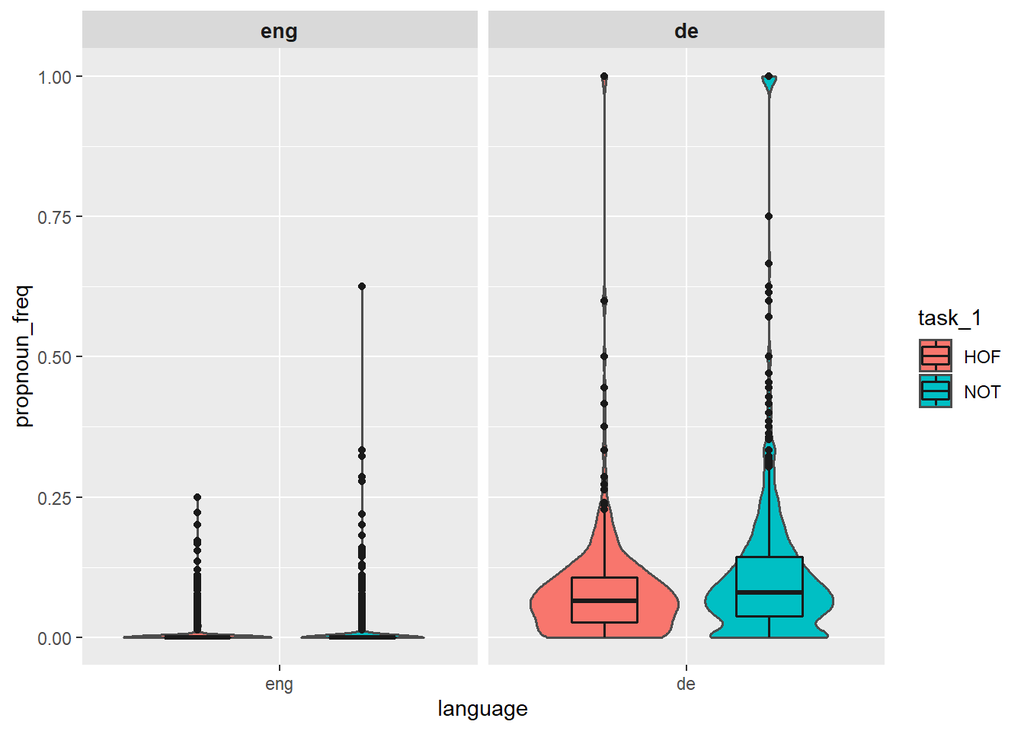

```r
p_punct <- ggplot(full_df, aes(x=language, y=propnoun_freq, fill=task_1))
dodge <- position_dodge(width=1)
p_punct + geom_violin(size=0.6, color="grey30", position=dodge) +
geom_boxplot(width=0.4, size=0.6, color="grey10", position=dodge, color="grey") +
facet_grid(cols = vars(language), scales="free", space="free") +
theme(
    strip.text.x = element_text(
      size = 10, face = "bold"
      ),
    strip.text.y = element_text(
      size = 10, face = "bold"
      )
    )
```

*Frequency of adjectives*

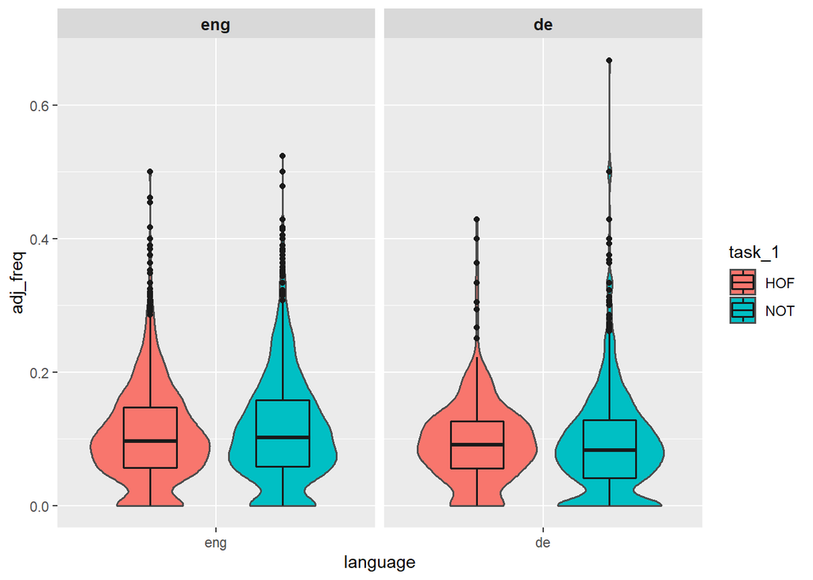

```r
p_punct <- ggplot(full_df, aes(x=language, y=adj_freq, fill=task_1))
dodge <- position_dodge(width=1)
p_punct + geom_violin(size=0.6, color="grey30", position=dodge) +
geom_boxplot(width=0.4, size=0.6, color="grey10", position=dodge, color="grey") +
facet_grid(cols = vars(language), scales="free", space="free") +
theme(
    strip.text.x = element_text(
      size = 10, face = "bold"
      ),
    strip.text.y = element_text(
      size = 10, face = "bold"
      )
    )
```

*Frequency of verbs*

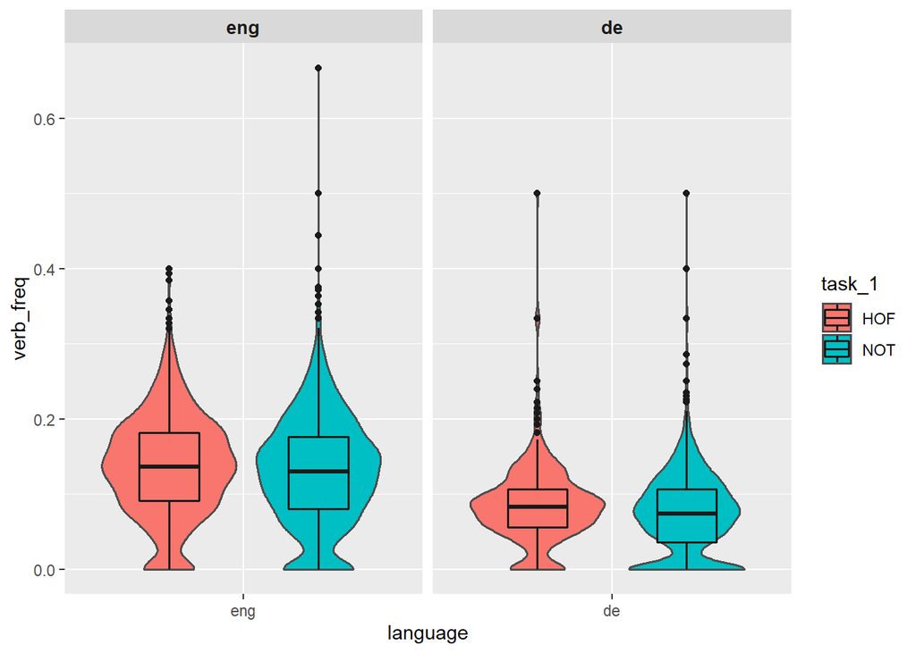

```r
p_punct <- ggplot(full_df, aes(x=language, y=verb_freq, fill=task_1))
dodge <- position_dodge(width=1)
p_punct + geom_violin(size=0.6, color="grey30", position=dodge) +
geom_boxplot(width=0.4, size=0.6, color="grey10", position=dodge, color="grey") +
facet_grid(cols = vars(language), scales="free", space="free") +
theme(
    strip.text.x = element_text(
      size = 10, face = "bold"
      ),
    strip.text.y = element_text(
      size = 10, face = "bold"
      )
    )
```

*Text length*

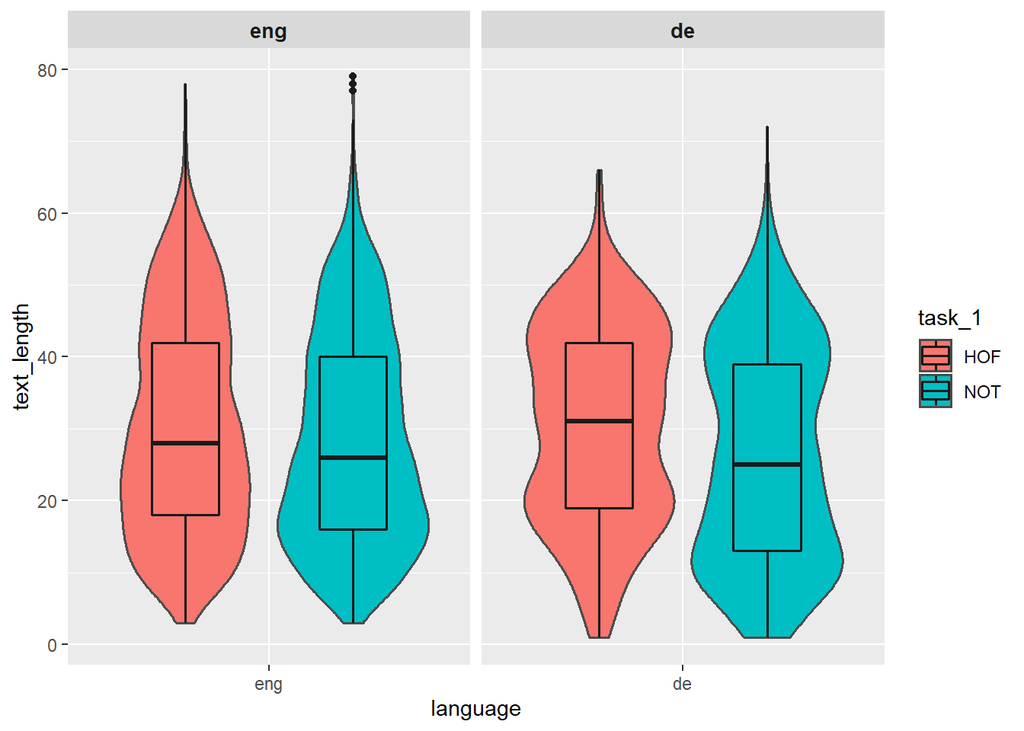

```r
p_punct <- ggplot(full_df, aes(x=language, y=text_length, fill=task_1))
dodge <- position_dodge(width=1)
p_punct + geom_violin(size=0.6, color="grey30", position=dodge) +
geom_boxplot(width=0.4, size=0.6, color="grey10", position=dodge, color="grey") +
facet_grid(cols = vars(language), scales="free", space="free") +
theme(
    strip.text.x = element_text(
      size = 10, face = "bold"
      ),
    strip.text.y = element_text(
      size = 10, face = "bold"
      )
    )
```

#### Commentary on the graphs

By looking at the boxplots above, there seems not to be a sharp difference in the distribution of the parameters in relation with the presence or not of Hate Speech in the text. The only feature that seems to present a slightly sharper difference in the two classes is text length in German texts.

### Correlation between text length and misspell frequency

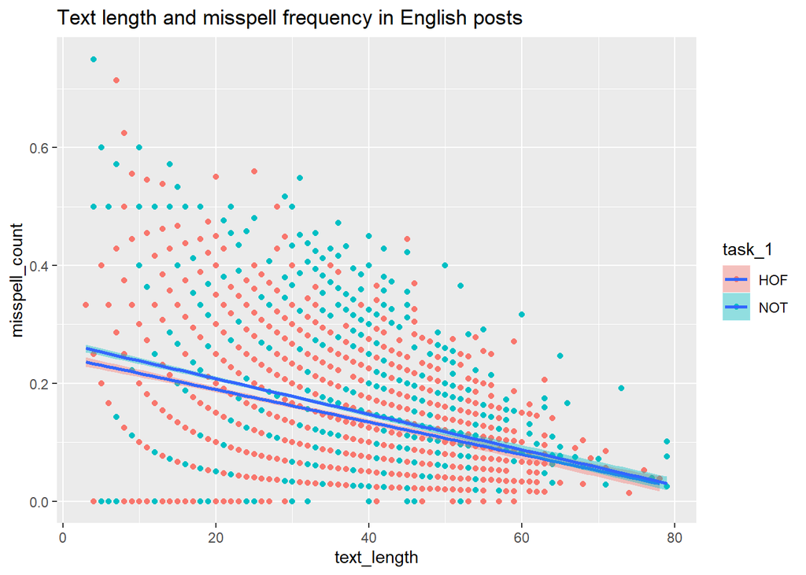

```r
ggplot(df_eng, aes(x=text_length, y=misspell_count, fill=task_1)) + geom_point(aes(color=task_1)) + geom_smooth(method=lm) + ggtitle("Text length and misspell frequency in English posts")
```

```r
t.test(df_eng$misspell_count, df_eng$text_length)
```

```
##
##  Welch Two Sample t-test
##
## data:  df_eng$misspell_count and df_eng$text_length
## t = -150.13, df = 5851.6, p-value < 2.2e-16
## alternative hypothesis: true difference in means is not equal to 0
## 95 percent confidence interval:
##  -29.29705 -28.54180
## sample estimates:
##  mean of x  mean of y
##  0.1745611 29.0939850
```

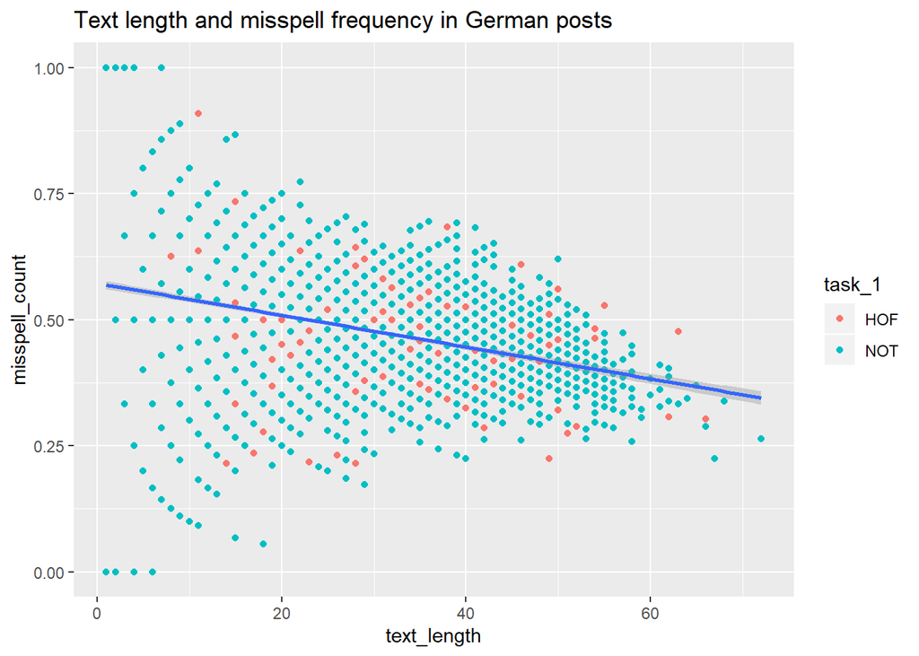

```r
ggplot(df_de, aes(x=text_length, y=misspell_count)) + geom_point(aes(color=task_1)) + geom_smooth(method=lm) + ggtitle("Text length and misspell frequency in German posts")
```

```r
t.test(df_de$misspell_count, df_de$text_length)
```

```
##
##  Welch Two Sample t-test
##
## data:  df_de$misspell_count and df_de$text_length
## t = -108.66, df = 3817.7, p-value < 2.2e-16
## alternative hypothesis: true difference in means is not equal to 0
## 95 percent confidence interval:
##  -26.73260 -25.78504
## sample estimates:
##  mean of x  mean of y
##  0.4876427 26.7464641
```

## 6. Statistical tests and modeling results

As stated above, I will run an unpaired t-test on all the dataset parameters, trying to compare the two classes of hateful and non-hateful posts. First of all, I will present the results regarding the English dataset, then those of the German dataset. When comparing the frequency of misspells in the text I will run a one-tailed t-test, with the null hypothesis that the frequency of misspells is higher in posts containing Hate Speech, because of the emotional state the user is in when writing the post (check the hypotheses section). Then, I will run a two-tailed t-test when comparing all the other parameters, with the null-hypothesis that parameters are equal both in HOF and NOT subsets, to verify whether this assumption holds or not.

### t-testing on the English dataset

```r
df_eng_HOF <- df_eng[df_eng$task_1 == "HOF",]
df_eng_NOT <- df_eng[df_eng$task_1 == "NOT",]
```

*t-test on misspell frequency*
H0:
$$misspell\_count_{NOT} \lt misspell\_count_{HOF}$$
H1:
$$misspell\_count_{NOT} \gt misspell\_count_{HOF}$$

```r
t.test(df_eng_NOT$misspell_count, df_eng_HOF$misspell_count, alternative = "greater", var.equal = FALSE)
```

```
##
##  Welch Two Sample t-test
##
## data:  df_eng_NOT$misspell_count and df_eng_HOF$misspell_count
## t = 7.7667, df = 5065.9, p-value = 4.842e-15
## alternative hypothesis: true difference in means is greater than 0
## 95 percent confidence interval:
##  0.01703306        Inf
## sample estimates:
## mean of x mean of y
## 0.1829107 0.1613000
```

H0:
$$param\_count_{NOT} = param\_count_{HOF}$$
H1:
$$param\_count_{NOT} = param\_count_{HOF}$$
*Frequency of punctuation*

```r
t.test(df_eng_NOT$punct_freq, df_eng_HOF$punct_freq, var.equal = FALSE)
```

```
##
##  Welch Two Sample t-test
##
## data:  df_eng_NOT$punct_freq and df_eng_HOF$punct_freq
## t = 1.8517, df = 4928.7, p-value = 0.06413
## alternative hypothesis: true difference in means is not equal to 0
## 95 percent confidence interval:
##  -0.0003460218  0.0121275273
## sample estimates:
## mean of x mean of y
## 0.2564696 0.2505788
```

*Text length*

```r
t.test(df_eng_NOT$text_length, df_eng_HOF$text_length, var.equal = FALSE)
```

```
##
##  Welch Two Sample t-test
##
## data:  df_eng_NOT$text_length and df_eng_HOF$text_length
## t = -4.8306, df = 4688.7, p-value = 1.404e-06
## alternative hypothesis: true difference in means is not equal to 0
## 95 percent confidence interval:
##  -2.700867 -1.141484
## sample estimates:
## mean of x mean of y
##  28.35171  30.27289
```

*Frequency of nouns*

```r
t.test(df_eng_NOT$noun_freq, df_eng_HOF$noun_freq, var.equal = FALSE)
```

```
##
##  Welch Two Sample t-test
##
## data:  df_eng_NOT$noun_freq and df_eng_HOF$noun_freq
## t = 2.5834, df = 4909.3, p-value = 0.009811
## alternative hypothesis: true difference in means is not equal to 0
## 95 percent confidence interval:
##  0.001600627 0.011674542
## sample estimates:
## mean of x mean of y
## 0.2741958 0.2675582
```

*Frequency of proper nouns*

```r
t.test(df_eng_NOT$propnoun_freq, df_eng_HOF$propnoun_freq, var.equal = FALSE)
```

```
##
##  Welch Two Sample t-test
##
## data:  df_eng_NOT$propnoun_freq and df_eng_HOF$propnoun_freq
## t = 1.5269, df = 5672.6, p-value = 0.1268
## alternative hypothesis: true difference in means is not equal to 0
## 95 percent confidence interval:
##  -0.0002382862  0.0019171927
## sample estimates:
##   mean of x   mean of y
## 0.005901280 0.005061826
```

*Frequency of adjectives*

```r
t.test(df_eng_NOT$adj_freq, df_eng_HOF$adj_freq, var.equal = FALSE)
```

```
##
##  Welch Two Sample t-test
##
## data:  df_eng_NOT$adj_freq and df_eng_HOF$adj_freq
## t = 3.9025, df = 5139.5, p-value = 9.643e-05
## alternative hypothesis: true difference in means is not equal to 0
## 95 percent confidence interval:
##  0.00394526 0.01191038
## sample estimates:
## mean of x mean of y
## 0.1137231 0.1057952
```

*Frequency of verbs*

```r
t.test(df_eng_NOT$verb_freq, df_eng_HOF$verb_freq, var.equal = FALSE)
```

```
##
##  Welch Two Sample t-test
##
## data:  df_eng_NOT$verb_freq and df_eng_HOF$verb_freq
## t = -3.5141, df = 5029.7, p-value = 0.0004452
## alternative hypothesis: true difference in means is not equal to 0
## 95 percent confidence interval:
##  -0.01048055 -0.00297433
## sample estimates:
## mean of x mean of y
## 0.1291132 0.1358407
```

### t-testing on the German dataset

```r
df_de_HOF <- df_de[df_de$task_1 == "HOF",]
df_de_NOT <- df_de[df_de$task_1 == "NOT",]
```

*t-test on misspell frequency*  
H0: $misspell\_count_{NOT} \lt misspell\_count_{HOF}$ H1: $misspell\_count_{NOT} \gt misspell\_count_{HOF}$

```r
t.test(df_de_NOT$misspell_count, df_de_HOF$misspell_count, alternative = "greater", var.equal = FALSE)
```

```
##
##  Welch Two Sample t-test
##
## data:  df_de_NOT$misspell_count and df_de_HOF$misspell_count
## t = 2.234, df = 602.34, p-value = 0.01292
## alternative hypothesis: true difference in means is greater than 0
## 95 percent confidence interval:
##  0.003348091         Inf
## sample estimates:
## mean of x mean of y
## 0.4890019 0.4762517
```

H0: $param\_count_{NOT} = param\_count_{HOF}$ H1: $param\_count_{NOT} = param\_count_{HOF}$ *Frequency of punctuation*

```r
t.test(df_de_NOT$punct_freq, df_de_HOF$punct_freq, var.equal = FALSE)
```

```
##
##  Welch Two Sample t-test
##
## data:  df_de_NOT$punct_freq and df_de_HOF$punct_freq
## t = 1.9073, df = 525.24, p-value = 0.05703
## alternative hypothesis: true difference in means is not equal to 0
## 95 percent confidence interval:
##  -0.0004117776  0.0278756357
## sample estimates:
## mean of x mean of y
## 0.2334165 0.2196846
```

*Text length*

```r
t.test(df_de_NOT$text_length, df_de_HOF$text_length, var.equal = FALSE)
```

```
##
##  Welch Two Sample t-test
##
## data:  df_de_NOT$text_length and df_de_HOF$text_length
## t = -5.7566, df = 533.1, p-value = 1.45e-08
## alternative hypothesis: true difference in means is not equal to 0
## 95 percent confidence interval:
##  -5.544762 -2.723294
## sample estimates:
## mean of x mean of y
##  26.30578  30.43980
```

*Frequency of nouns*

```r
t.test(df_de_NOT$noun_freq, df_de_HOF$noun_freq, var.equal = FALSE)
```

```
##
##  Welch Two Sample t-test
##
## data:  df_de_NOT$noun_freq and df_de_HOF$noun_freq
## t = 2.7428, df = 566.73, p-value = 0.006284
## alternative hypothesis: true difference in means is not equal to 0
## 95 percent confidence interval:
##  0.002611032 0.015783821
## sample estimates:
## mean of x mean of y
## 0.1213728 0.1121754
```

*Frequency of proper nouns*

```r
t.test(df_de_NOT$propnoun_freq, df_de_HOF$propnoun_freq, var.equal = FALSE)
```

```
##
##  Welch Two Sample t-test
##
## data:  df_de_NOT$propnoun_freq and df_de_HOF$propnoun_freq
## t = 5.677, df = 635.83, p-value = 2.086e-08
## alternative hypothesis: true difference in means is not equal to 0
## 95 percent confidence interval:
##  0.02305880 0.04744736
## sample estimates:
##  mean of x  mean of y
## 0.12113815 0.08588507
```

*Frequency of adjectives*

```r
t.test(df_de_NOT$adj_freq, df_de_HOF$adj_freq, var.equal = FALSE)
```

```
##
##  Welch Two Sample t-test
##
## data:  df_de_NOT$adj_freq and df_de_HOF$adj_freq
## t = -0.49158, df = 571.48, p-value = 0.6232
## alternative hypothesis: true difference in means is not equal to 0
## 95 percent confidence interval:
##  -0.008451496  0.005067865
## sample estimates:
##  mean of x  mean of y
## 0.09391940 0.09561122
```

*Frequency of verbs*

```r
t.test(df_de_NOT$verb_freq, df_de_HOF$verb_freq, var.equal = FALSE)
```

```
##
##  Welch Two Sample t-test
##
## data:  df_de_NOT$verb_freq and df_de_HOF$verb_freq
## t = -4.276, df = 502.41, p-value = 2.278e-05
## alternative hypothesis: true difference in means is not equal to 0
## 95 percent confidence interval:
##  -0.017763728 -0.006578969
## sample estimates:
##  mean of x  mean of y
## 0.07249186 0.08466321
```

#### Comment on t-tests for the German dataset

T-tests on the German dataset present similar results compared to those run on the English dataset. As for English, also for german the null hypothesis stating that there are more misspells in hateful texts must be rejected, given the p-value < 0.05. As of the other parameters, only punctuation and adjective frequencies seem to “pass” the test, with p-value = 0.05703 for the former and p-value = 0.6232 for the latter. All the other linguistic parameters, once again, seem not to be representative of a strong distinction between classes, the p-values obtained from testing are way too little.

### Logistic regression for the English dataset

$$\log(odds(HOF)) = \beta_o + \beta_1 \times misspell\_count + \beta_2 \times text\_length$$

```r
lr1_eng <- glm(binary_classification ~ misspell_count + text_length,
                data=df_eng,
                family="binomial")
summary(lr1_eng)
```

```
##
## Call:
## glm(formula = binary_classification ~ misspell_count + text_length,
##     family = "binomial", data = df_eng)
##
## Deviance Residuals:
##     Min       1Q   Median       3Q      Max
## -1.1710  -1.0115  -0.9035   1.3204   1.8825
##
## Coefficients:
##                 Estimate Std. Error z value Pr(>|z|)
## (Intercept)    -0.267794   0.093979  -2.850  0.00438 **
## misspell_count -1.777200   0.287610  -6.179 6.44e-10 ***
## text_length     0.003767   0.001993   1.891  0.05869 .
## ---
## Signif. codes:  0 '***' 0.001 '**' 0.01 '*' 0.05 '.' 0.1 ' ' 1
##
## (Dispersion parameter for binomial family taken to be 1)
##
##     Null deviance: 7807.7  on 5851  degrees of freedom
## Residual deviance: 7745.1  on 5849  degrees of freedom
## AIC: 7751.1
##
## Number of Fisher Scoring iterations: 4
```

*log-odd of the coefficients*

```r
1/(1+exp(0.267794))
```

```
## [1] 0.4334487
```

```r
1/(1+exp(1.777200))
```

```
## [1] 0.1446492
```

```r
1/(1+exp(-0.003767))
```

```
## [1] 0.5009417
```

*ANOVA and Accuracy test*

```r
lr1_eng.0 <- glm(binary_classification ~ 1,
                data=df_eng,
                family="binomial")
anova(lr1_eng, lr1_eng.0, test="Chisq")
```

```
## Analysis of Deviance Table
##
## Model 1: binary_classification ~ misspell_count + text_length
## Model 2: binary_classification ~ 1
##   Resid. Df Resid. Dev Df Deviance  Pr(>Chi)
## 1      5849     7745.1
## 2      5851     7807.7 -2  -62.556 2.607e-14 ***
## ---
## Signif. codes:  0 '***' 0.001 '**' 0.01 '*' 0.05 '.' 0.1 ' ' 1
```

```r
lrAcc(lr1_eng, "binary_classification")
```

```
## [1] 0.6136364
```

$$\log(odds(HOF)) = \beta_o + \beta_1 \times misspell\_count + \beta_2 \times text\_length + \beta_3 \times noun\_freq$$

```r
lr2_eng <- glm(binary_classification ~ misspell_count + text_length + noun_freq,
                data=df_eng,
                family="binomial")
summary(lr2_eng)
```

```
##
## Call:
## glm(formula = binary_classification ~ misspell_count + text_length +
##     noun_freq, family = "binomial", data = df_eng)
##
## Deviance Residuals:
##     Min       1Q   Median       3Q      Max
## -1.1695  -1.0119  -0.9038   1.3204   1.9191
##
## Coefficients:
##                 Estimate Std. Error z value Pr(>|z|)
## (Intercept)    -0.204289   0.128748  -1.587   0.1126
## misspell_count -1.757111   0.288910  -6.082 1.19e-09 ***
## text_length     0.003461   0.002037   1.699   0.0893 .
## noun_freq      -0.214158   0.296988  -0.721   0.4708
## ---
## Signif. codes:  0 '***' 0.001 '**' 0.01 '*' 0.05 '.' 0.1 ' ' 1
##
## (Dispersion parameter for binomial family taken to be 1)
##
##     Null deviance: 7807.7  on 5851  degrees of freedom
## Residual deviance: 7744.6  on 5848  degrees of freedom
## AIC: 7752.6
##
## Number of Fisher Scoring iterations: 4
```

*log-odd of the coefficients*

```r
1/(1+exp(0.204289))
```

```
## [1] 0.4491046
```

```r
1/(1+exp(1.757111))
```

```
## [1] 0.1471525
```

```r
1/(1+exp(-0.003461))
```

```
## [1] 0.5008652
```

```r
1/(1+exp(0.214158))
```

```
## [1] 0.4466642
```

*ANOVA and Accuracy test*

```r
print(anova(lr2_eng, lr1_eng.0, test="Chisq"))
```

```
## Analysis of Deviance Table
##
## Model 1: binary_classification ~ misspell_count + text_length + noun_freq
## Model 2: binary_classification ~ 1
##   Resid. Df Resid. Dev Df Deviance  Pr(>Chi)
## 1      5848     7744.6
## 2      5851     7807.7 -3  -63.077 1.293e-13 ***
## ---
## Signif. codes:  0 '***' 0.001 '**' 0.01 '*' 0.05 '.' 0.1 ' ' 1
```

```r
lrAcc(lr2_eng, "binary_classification")
```

```
## [1] 0.6136364
```

$$logit(P(y_i = 1)) = \beta_0 + \alpha_{0,j[i]} + (\beta_{misspell\_count} + \alpha_{misspell\_count}) \times misspell\_count + (\beta_{text\_length} + \alpha_{text\_length}) \times text\_length$$

```r
lr1_mer_eng <- glmer(binary_classification ~ misspell_count + text_length +
                  (1 + misspell_count + text_length||X),
                data=df_eng,
                family="binomial",
                control=glmerControl(optimizer = "bobyqa"))
```

```
## boundary (singular) fit: see ?isSingular
```

```r
summary(lr1_mer_eng)
```

```
## Generalized linear mixed model fit by maximum likelihood (Laplace
##   Approximation) [glmerMod]
##  Family: binomial  ( logit )
## Formula:
## binary_classification ~ misspell_count + text_length + (1 + misspell_count +
##     text_length || X)
##    Data: df_eng
## Control: glmerControl(optimizer = "bobyqa")
##
##      AIC      BIC   logLik deviance df.resid
##   7757.0   7797.0  -3872.5   7745.0     5846
##
## Scaled residuals:
##     Min      1Q  Median      3Q     Max
## -0.9948 -0.8145 -0.7017  1.1770  1.9719
##
## Random effects:
##  Groups Name           Variance Std.Dev.
##  X      (Intercept)    0.0000   0.0000
##  X.1    misspell_count 0.5906   0.7685
##  X.2    text_length    0.0000   0.0000
## Number of obs: 5852, groups:  X, 5852
##
## Fixed effects:
##                 Estimate Std. Error z value Pr(>|z|)
## (Intercept)    -0.262533   0.095491  -2.749  0.00597 **
## misspell_count -1.833173   0.328857  -5.574 2.48e-08 ***
## text_length     0.003780   0.002001   1.889  0.05886 .
## ---
## Signif. codes:  0 '***' 0.001 '**' 0.01 '*' 0.05 '.' 0.1 ' ' 1
##
## Correlation of Fixed Effects:
##             (Intr) msspl_
## misspll_cnt -0.739
## text_length -0.820  0.342
## convergence code: 0
## boundary (singular) fit: see ?isSingular
```

*log-odd of the coefficients*

```r
1/(1+exp(0.262533))
```

```
## [1] 0.4347411
```

```r
1/(1+exp(1.833173))
```

```
## [1] 0.1378607
```

```r
1/(1+exp(-0.003780))
```

```
## [1] 0.500945
```

*ANOVA and Accuracy test*

```r
lr1_mer_eng.0 <- glmer(binary_classification ~ (1|X),
                data=df_eng,
                family="binomial")
```

```
## boundary (singular) fit: see ?isSingular
```

```r
anova(lr1_mer_eng.0, lr1_mer_eng)
```

```
## Data: df_eng
## Models:
## lr1_mer_eng.0: binary_classification ~ (1 | X)
## lr1_mer_eng: binary_classification ~ misspell_count + text_length + (1 + misspell_count +
## lr1_mer_eng:     text_length || X)
##               Df    AIC  BIC  logLik deviance  Chisq Chi Df Pr(>Chisq)
## lr1_mer_eng.0  2 7811.7 7825 -3903.8   7807.7
## lr1_mer_eng    6 7757.0 7797 -3872.5   7745.0 62.693      4  7.874e-13 ***
## ---
## Signif. codes:  0 '***' 0.001 '**' 0.01 '*' 0.05 '.' 0.1 ' ' 1
```

```r
lrAcc(lr1_mer_eng, "binary_classification")
```

```
## [1] 0.6136364
```

$$logit(P(y_i = 1)) = \beta_0 + \alpha_{0,j[i]} + (\beta_{misspell\_count} + \alpha_{misspell\_count}) \times misspell\_count + (\beta_{text\_length} + \alpha_{text\_length}) \times text\_length + (\beta_{noun\_freq} + \alpha_{noun\_freq}) \times noun\_freq$$

```r
lr2_mer_eng <- glmer(binary_classification ~ misspell_count + text_length + noun_freq +
                  (1 + misspell_count + text_length + noun_freq||X),
                data=df_eng,
                family="binomial",
                control=glmerControl(optimizer = "bobyqa"))
```

```
## boundary (singular) fit: see ?isSingular
```

```r
summary(lr2_mer_eng)
```

```
## Generalized linear mixed model fit by maximum likelihood (Laplace
##   Approximation) [glmerMod]
##  Family: binomial  ( logit )
## Formula: binary_classification ~ misspell_count + text_length + noun_freq +
##     (1 + misspell_count + text_length + noun_freq || X)
##    Data: df_eng
## Control: glmerControl(optimizer = "bobyqa")
##
##      AIC      BIC   logLik deviance df.resid
##   7760.2   7813.5  -3872.1   7744.2     5844
##
## Scaled residuals:
##     Min      1Q  Median      3Q     Max
## -0.9876 -0.8093 -0.6997  1.1685  2.0911
##
## Random effects:
##  Groups Name           Variance  Std.Dev.
##  X      (Intercept)    3.959e-10 0.0000199
##  X.1    misspell_count 2.688e-05 0.0051848
##  X.2    text_length    0.000e+00 0.0000000
##  X.3    noun_freq      5.668e-01 0.7528631
## Number of obs: 5852, groups:  X, 5852
##
## Fixed effects:
##                 Estimate Std. Error z value Pr(>|z|)
## (Intercept)    -0.190738   0.131716  -1.448   0.1476
## misspell_count -1.788508   0.295955  -6.043 1.51e-09 ***
## text_length     0.003512   0.002058   1.707   0.0879 .
## noun_freq      -0.271794   0.315334  -0.862   0.3887
## ---
## Signif. codes:  0 '***' 0.001 '**' 0.01 '*' 0.05 '.' 0.1 ' ' 1
##
## Correlation of Fixed Effects:
##             (Intr) msspl_ txt_ln
## misspll_cnt -0.505
## text_length -0.718  0.356
## noun_freq   -0.692 -0.042  0.182
## convergence code: 0
## boundary (singular) fit: see ?isSingular
```

*log-odd of the coefficients*

```r
1/(1+exp(0.190738))
```

```
## [1] 0.4524595
```

```r
1/(1+exp(1.788508))
```

```
## [1] 0.1432557
```

```r
1/(1+exp(-0.003512))
```

```
## [1] 0.500878
```

```r
1/(1+exp(0.271794))
```

```
## [1] 0.4324667
```

*ANOVA and Accuracy test*

```r
print(anova(lr1_mer_eng.0, lr2_mer_eng))
```

```
## Data: df_eng
## Models:
## lr1_mer_eng.0: binary_classification ~ (1 | X)
## lr2_mer_eng: binary_classification ~ misspell_count + text_length + noun_freq +
## lr2_mer_eng:     (1 + misspell_count + text_length + noun_freq || X)
##               Df    AIC    BIC  logLik deviance  Chisq Chi Df Pr(>Chisq)
## lr1_mer_eng.0  2 7811.7 7825.0 -3903.8   7807.7
## lr2_mer_eng    8 7760.2 7813.5 -3872.1   7744.2 63.512      6   8.68e-12 ***
## ---
## Signif. codes:  0 '***' 0.001 '**' 0.01 '*' 0.05 '.' 0.1 ' ' 1
```

```r
lrAcc(lr2_mer_eng, "binary_classification")
```

```
## [1] 0.6138072
```

#### Comment on Logistic models for the English dataset

First of all, the coefficients of the various models can be interpreted only after calculating the logarithm of the odds of the given values. The first intercept log-odd tells us about the probability of a randomly sampled text to be offensive (HOF or 1) in case all the other variables were equal to 0.

The log-odd of the coefficients of all the other independent variables represent the change in probability for a text to be offensive in case there is a unit-change in the value of the correspondent variable. For instance, in the model lr1, the coefficient of **misspell_count** is -1.777200, the log-odd of which is 0.1446492. This means that, at every positive unit-change in the value of misspell_count, the text is 14% less probable to be offensive (since the coefficient is negative). This also makes sense when looking at the boxplots and at the mean value of this two parameter - the misspell count is slightly higher in non-offensive texts, contrary to the expectations expressed at the beginning of this research. It is also consistent with the t-tests that were previosuly carried out.

Regarding ANOVA, we can have a picture of the model by looking at the colum “Chisq Chi” (the column is just called “Deviance” for non-mixed-effect models), which, for the model lr1_mer_eng presents the value 62.693. This value expresses the deviance from a model with no added parameters, which means that the parameters we used to trained the model improve the ability of the model to classify the texts.

The four models all present the same value of accuracy, 0.613. Also the results on the ANOVA tests are very similar, the deviance for the models is, respectively, 62.556, 63.077, 62.693, and 63.512. There seems not to be a strong difference between mixed-feature and normal models.

### Logistic Regression for the German dataset

$$\log(odds(HOF)) = \beta_o + \beta_1 \times misspell\_count + \beta_2 \times text\_length$$

```r
lr1_de <- glm(binary_classification ~ misspell_count + text_length,
                data=df_de,
                family="binomial")
summary(lr1_de)
```

```
##
## Call:
## glm(formula = binary_classification ~ misspell_count + text_length,
##     family = "binomial", data = df_de)
##
## Deviance Residuals:
##     Min       1Q   Median       3Q      Max
## -0.6891  -0.5162  -0.4490  -0.4035   2.3293
##
## Coefficients:
##                 Estimate Std. Error z value Pr(>|z|)
## (Intercept)    -2.634780   0.278152  -9.472  < 2e-16 ***
## misspell_count -0.027701   0.447830  -0.062    0.951
## text_length     0.018407   0.003746   4.914 8.92e-07 ***
## ---
## Signif. codes:  0 '***' 0.001 '**' 0.01 '*' 0.05 '.' 0.1 ' ' 1
##
## (Dispersion parameter for binomial family taken to be 1)
##
##     Null deviance: 2591.3  on 3817  degrees of freedom
## Residual deviance: 2563.5  on 3815  degrees of freedom
## AIC: 2569.5
##
## Number of Fisher Scoring iterations: 5
```

*log-odd of the coefficients*

```r
1/(1+exp(2.634780))
```

```
## [1] 0.06693331
```

```r
1/(1+exp(0.027701))
```

```
## [1] 0.4930752
```

```r
1/(1+exp(-0.018407))
```

```
## [1] 0.5046016
```

*ANOVA and Accuracy test*

```r
lr1_de.0 <- glm(binary_classification ~ 1,
                data=df_de,
                family="binomial")
anova(lr1_de, lr1_de.0, test="Chisq")
```

```
## Analysis of Deviance Table
##
## Model 1: binary_classification ~ misspell_count + text_length
## Model 2: binary_classification ~ 1
##   Resid. Df Resid. Dev Df Deviance  Pr(>Chi)
## 1      3815     2563.5
## 2      3817     2591.3 -2  -27.761 9.371e-07 ***
## ---
## Signif. codes:  0 '***' 0.001 '**' 0.01 '*' 0.05 '.' 0.1 ' ' 1
```

```r
lrAcc(lr1_de, "binary_classification")
```

```
## [1] 0.8933997
```

$$\log(odds(HOF)) = \beta_o + \beta_1 \times misspell\_count + \beta_2 \times text\_length + \beta_3 \times noun\_freq$$

```r
lr2_de <- glm(binary_classification ~ misspell_count + text_length + noun_freq,
                data=df_de,
                family="binomial")
summary(lr2_de)
```

```
##
## Call:
## glm(formula = binary_classification ~ misspell_count + text_length +
##     noun_freq, family = "binomial", data = df_de)
##
## Deviance Residuals:
##     Min       1Q   Median       3Q      Max
## -0.7563  -0.5106  -0.4515  -0.3984   2.5259
##
## Coefficients:
##                 Estimate Std. Error z value Pr(>|z|)
## (Intercept)    -2.442074   0.279995  -8.722  < 2e-16 ***
## misspell_count  0.051506   0.436266   0.118  0.90602
## text_length     0.019909   0.003774   5.276 1.32e-07 ***
## noun_freq      -2.348986   0.787763  -2.982  0.00287 **
## ---
## Signif. codes:  0 '***' 0.001 '**' 0.01 '*' 0.05 '.' 0.1 ' ' 1
##
## (Dispersion parameter for binomial family taken to be 1)
##
##     Null deviance: 2591.3  on 3817  degrees of freedom
## Residual deviance: 2554.3  on 3814  degrees of freedom
## AIC: 2562.3
##
## Number of Fisher Scoring iterations: 5
```

*log-odd of the coefficients*

```r
1/(1+exp(2.442074))
```

```
## [1] 0.0800201
```

```r
1/(1+exp(-0.051506))
```

```
## [1] 0.5128737
```

```r
1/(1+exp(-0.019909))
```

```
## [1] 0.5049771
```

```r
1/(1+exp(2.348986))
```

```
## [1] 0.0871464
```

*ANOVA and Accuracy test*

```r
print(anova(lr2_de, lr1_de.0, test="Chisq"))
```

```
## Analysis of Deviance Table
##
## Model 1: binary_classification ~ misspell_count + text_length + noun_freq
## Model 2: binary_classification ~ 1
##   Resid. Df Resid. Dev Df Deviance  Pr(>Chi)
## 1      3814     2554.3
## 2      3817     2591.3 -3  -36.952 4.711e-08 ***
## ---
## Signif. codes:  0 '***' 0.001 '**' 0.01 '*' 0.05 '.' 0.1 ' ' 1
```

```r
lrAcc(lr2_de, "binary_classification")
```

```
## [1] 0.8933997
```

$$logit(P(y_i = 1)) = \beta_0 + \alpha_{0,j[i]} + (\beta_{misspell\_count} + \alpha_{misspell\_count}) \times misspell\_count + (\beta_{text\_length} + \alpha_{text\_length}) \times text\_length$$

```r
lr1_mer_de <- glmer(binary_classification ~ misspell_count + text_length +
                  (1 + misspell_count + text_length||X),
                data=df_de,
                family="binomial",
                control=glmerControl(optimizer = "bobyqa"))
summary(lr1_mer_de)
```

```
## Generalized linear mixed model fit by maximum likelihood (Laplace
##   Approximation) [glmerMod]
##  Family: binomial  ( logit )
## Formula:
## binary_classification ~ misspell_count + text_length + (1 + misspell_count +
##     text_length || X)
##    Data: df_de
## Control: glmerControl(optimizer = "bobyqa")
##
##      AIC      BIC   logLik deviance df.resid
##   1287.7   1325.1   -637.8   1275.7     3812
##
## Scaled residuals:
##       Min        1Q    Median        3Q       Max
## -0.003518 -0.002542 -0.001985 -0.001523  0.147189
##
## Random effects:
##  Groups Name           Variance Std.Dev.
##  X      (Intercept)    716.300  26.764
##  X.1    misspell_count  13.286   3.645
##  X.2    text_length      1.822   1.350
## Number of obs: 3818, groups:  X, 3818
##
## Fixed effects:
##                 Estimate Std. Error z value Pr(>|z|)
## (Intercept)    -11.25585    1.51825  -7.414 1.23e-13 ***
## misspell_count  -0.38648    2.16837  -0.178    0.859
## text_length     -0.03524    0.03471  -1.015    0.310
## ---
## Signif. codes:  0 '***' 0.001 '**' 0.01 '*' 0.05 '.' 0.1 ' ' 1
##
## Correlation of Fixed Effects:
##             (Intr) msspl_
## misspll_cnt -0.784
## text_length -0.662  0.149
## convergence code: 1
## unable to evaluate scaled gradient
## Model failed to converge: degenerate  Hessian with 1 negative eigenvalues
```

```r
lr1_mer_de.0 <- glmer(binary_classification ~ (1|X),
                data=df_de,
                family="binomial")
anova(lr1_mer_de.0, lr1_mer_de)
```

```
## Data: df_de
## Models:
## lr1_mer_de.0: binary_classification ~ (1 | X)
## lr1_mer_de: binary_classification ~ misspell_count + text_length + (1 + misspell_count +
## lr1_mer_de:     text_length || X)
##              Df    AIC    BIC  logLik deviance Chisq Chi Df Pr(>Chisq)
## lr1_mer_de.0  2 1274.2 1286.7 -635.10   1270.2
## lr1_mer_de    6 1287.7 1325.1 -637.83   1275.7     0      4          1
```

```r
lrAcc(lr1_mer_de, "binary_classification")
```

```
## [1] 1
```

$$logit(P(y_i = 1)) = \beta_0 + \alpha_{0,j[i]} + (\beta_{misspell\_count} + \alpha_{misspell\_count}) \times misspell\_count + (\beta_{text\_length} + \alpha_{text\_length}) \times text\_length + (\beta_{noun\_freq} + \alpha_{noun\_freq}) \times noun\_freq$$

```r
lr2_mer_de <- glmer(binary_classification ~ misspell_count + text_length + noun_freq +
                  (1 + misspell_count + text_length + noun_freq||X),
                data=df_de,
                family="binomial",
                control=glmerControl(optimizer = "bobyqa"))
summary(lr2_mer_de)
```

```
## Generalized linear mixed model fit by maximum likelihood (Laplace
##   Approximation) [glmerMod]
##  Family: binomial  ( logit )
## Formula: binary_classification ~ misspell_count + text_length + noun_freq +
##     (1 + misspell_count + text_length + noun_freq || X)
##    Data: df_de
## Control: glmerControl(optimizer = "bobyqa")
##
##      AIC      BIC   logLik deviance df.resid
##   1299.6   1349.6   -641.8   1283.6     3810
##
## Scaled residuals:
##       Min        1Q    Median        3Q       Max
## -0.006095 -0.003012 -0.001826 -0.001081  0.242551
##
## Random effects:
##  Groups Name           Variance Std.Dev.
##  X      (Intercept)    223.560  14.952
##  X.1    misspell_count  17.416   4.173
##  X.2    text_length      3.355   1.832
##  X.3    noun_freq        1.989   1.410
## Number of obs: 3818, groups:  X, 3818
##
## Fixed effects:
##                  Estimate Std. Error  z value Pr(>|z|)
## (Intercept)    -10.121179   0.001773 -5709.98   <2e-16 ***
## misspell_count  -0.107644   0.001772   -60.73   <2e-16 ***
## text_length     -0.070833   0.001750   -40.47   <2e-16 ***
## noun_freq       -3.048370   0.001831 -1665.28   <2e-16 ***
## ---
## Signif. codes:  0 '***' 0.001 '**' 0.01 '*' 0.05 '.' 0.1 ' ' 1
##
## Correlation of Fixed Effects:
##             (Intr) msspl_ txt_ln
## misspll_cnt  0.000
## text_length -0.001  0.000
## noun_freq    0.000  0.000  0.000
## convergence code: 0
## unable to evaluate scaled gradient
## Model failed to converge: degenerate  Hessian with 2 negative eigenvalues
```

```r
anova(lr1_mer_de.0, lr2_mer_de)
```

```
## Data: df_de
## Models:
## lr1_mer_de.0: binary_classification ~ (1 | X)
## lr2_mer_de: binary_classification ~ misspell_count + text_length + noun_freq +
## lr2_mer_de:     (1 + misspell_count + text_length + noun_freq || X)
##              Df    AIC    BIC  logLik deviance Chisq Chi Df Pr(>Chisq)
## lr1_mer_de.0  2 1274.2 1286.7 -635.10   1270.2
## lr2_mer_de    8 1299.6 1349.6 -641.79   1283.6     0      6          1
```

```r
lrAcc(lr2_mer_de, "binary_classification")
```

```
## [1] 1
```

#### Comment on Logistic models for the German dataset

The coefficients of the various models can be interpreted in the same way as for the models constructed on the English database. For instance, in the model lr1_de the coefficient for text length is equal to 0.018407, meaning that there is an increase in the probability for the text to be offensive at every positive unit-step. This, again, makes sense if we look at the boxplot that was presented above for text length. And again, it is also consistent with the t-test I ran.

The mixed-feature models failed to converge for German language.

### Decision Tree and Random Forest classifier for the English dataset

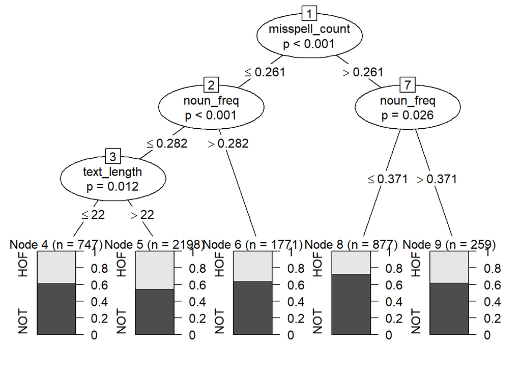

```r
fit_eng_tree <- ctree(task_1~misspell_count+punct_freq+adj_freq+propnoun_freq+verb_freq+text_length+noun_freq, data = df_eng)
plot(fit_eng_tree)
```

```r
fit_eng_forest <- cforest(task_1~misspell_count+text_length+noun_freq+punct_freq+adj_freq+propnoun_freq+verb_freq, data = df_eng, controls=cforest_unbiased(ntree=100, mtry=2))
varimp(fit_eng_forest)
```

```
## misspell_count    text_length      noun_freq     punct_freq       adj_freq
##   0.0050859266   0.0014444961   0.0015420344   0.0013701811   0.0010961449
##  propnoun_freq      verb_freq
##  -0.0014909429   0.0003251277
```

#### Comment on Decision Tree and Random Forest Classifier for English

By looking at the Decision Tree and Random Forest Classifier models, we can have a broader picture of the interaction between parameters. As we can see in the above picture, the Decision Tree algorithm divides the data points into five groups, taking into consideration the value of three parameters: misspell_count, noun_freq and text_length. However, we can notice that the 5 groups are very miscellaneous, there is no evident distinction among them. In Node 5, for instance, there is no clear prevalence of either class.

### Decision Tree and Random Forest classifier for the German dataset

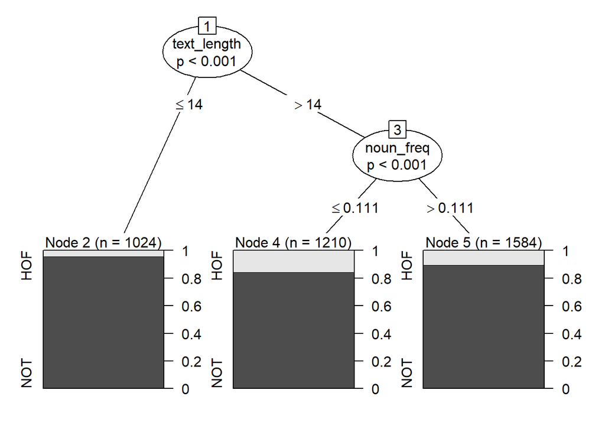

```r
fit_de_tree <- ctree(task_1~misspell_count+text_length+noun_freq, data = df_de)
plot(fit_de_tree)
```

```r
fit_de_forest <- cforest(task_1~misspell_count+text_length+noun_freq+punct_freq+adj_freq+propnoun_freq+verb_freq, data = df_de, controls=cforest_unbiased(ntree=100, mtry=2))
varimp(fit_de_forest)
```

```
## misspell_count    text_length      noun_freq     punct_freq       adj_freq
##   0.0004341637   0.0028256228   0.0025907473   0.0037580071  -0.0001423488
##  propnoun_freq      verb_freq
##   0.0004911032   0.0004128114
```

#### Comment on Decision Tree and Random Forest Classifier for German

By looking at the graph, there is always a prevalence of non-offensive texts in the three groups that the algorithm identifies. This, unfortunately, is due to a strong size imbalance between the two classes.

The Random Forest Classifier identifies text_length, punct_freq and noun_freq as the top-3 features. This is consistent with the interpretation we gave to text_length for German texts.

## 7.Conclusions

The data used for this research was taken from HASOC datasets. The texts are classified as Hate Speech or non-Hate-Speech. This brief reasearch provides a statistical analysis around some linguistical characteristics of the texts of the datasets, such as frequency of misspells or nouns. I tested the hypothesis that non-offensive texts contain fewer misspells than offensive one, because of the emotional state of the writer. Moreover, I tested the importance of different parameters in classifying the texts. The paper provides a visualisation of the data, along with a description of it, the results of the t-tests, and some observations on three classification models: Logistic Regression, Decision Tree, and Random Forest Classifier.

Data visualization and statistical testing provide similar picture of how data interelates. Apparently, there is no evidence to state that fewer misspells correspond to a less offensive text. T-testing on the datasets of both German and English seems to point to the opposite conclusion, instead: the more the misspells, the greater the probability that the text is not offensive. The null hypothesis is thus rejected. Parameters other than misspells seem not to provide much information on the nature of the text. It must be noted that for classifying English texts, proper noun and punctuation frequencies seem to be the least salient features, according to t-testing. Same holds for punctuation and adjective frequencies in German texts.

In general, t-tests point to the fact that some of the parameters (those with p-value < 0.05) present a certain difference in offensive and non-offensive texts. However, the classification models presented a slightly different picture: this parameters are not sufficient to provide a satisfactory classification of the texts. This is shown very clearly by the Tree and the Random Forest classfiers. Apparently, calculating the length of the text and a few other statistics is not sufficient to classify texts as offensive or not. In fact, if we look at the winners of the original competition, they all deployed very sofisticated NLP techniques to classify the texts. On the whole, it can be stated that extracting “offense” from a text is a difficult task, requiring more finely tuned algorithm to be tackled.

To conclude, this reaserch provided a very brief overview of some of the problems related to Hate Speech automatical detection. It was demonstrated how common-sense assumptions can be fully rejected by some simple statistical testing. It was also demonstrated that a few parameters are not sufficient to provide a complete picture of the texts. This supports the idea that reasearch in the field should be addressed with very well-engineered and impartial systems.

# Bibliography

- hasocfire, https://hasocfire.github.io/hasoc/2019/call_for_participation.html
- Rahman, Md Ataur (2020). “Exploring Features for Multi-label Hate Speech Detection.”
- Thomas Mandl et al. (2019), “Overview of the HASOC track at FIRE 2019: Hate Speech and Offensive Content Identification in Indo-European Languages.”
- HASOC website, https://hasocfire.github.io/hasoc/2019/dataset.html
- Github preprocessing link, https://github.com/lauberto/uni_mydirectory/tree/master/data_analysis
- Python spellchecker, https://pypi.org/project/pyspellchecker/
- Hannover POS tagger, http://textmining.wp.hs-hannover.de/Preprocessing.html